# Time Series Report

Time Series Analysis and Spatial Statistics - Umeå University

Artem Shiryaev

2024-03-14

## Introduction

In this report we will familiarize ourselves with time series analysis methods, applied to forecasting of log Bitcoin prices as our case study of choice. The format of the report is as follows, firstly we introduce the methods and provide a brief overview $-$ the curious reader may refer to the textbook by Peter J. Brockwell and Richard A. Davis, for more detailed explanations. Secondly, we will present the results of applying the methods covered on our case study of choice and lastly a brief discussion and conclusion will be drawn by judging the results of the analysis in a concise and clear manner.

# Methods

### Task 1

Find a time series data that (can) includes a seasonal component, for example, quarterly data, monthly data. Make sure that the series is fairly long, at least 10 years.

### Solution

We know from financial literature that pricing of assets can be strongly dependent on financial performance - likewise are cryptocurrencies heavily dependent on the overall markets performance and typically experience cycles. Thus, we continue by finding downloading daily prices of Bitcoin as our data set of choice from Yahoo Finance.

```r
# Load time series data, in this case daily Bitcoin prices
data <- read.csv("~/University/Education/Mathematics/Avancerade Kurser/VT24 Time Series/Assignments/Labb 1/UMU_Time_Series_VT24/BTC-USD.csv")

# Format the dataframe into a time series object
formated.data <- ts(data = data[,2:7],
                    start = c(2014, 288),
                    frequency = 365
)
```

Here we can see the aforementioned time series in Figure 1.

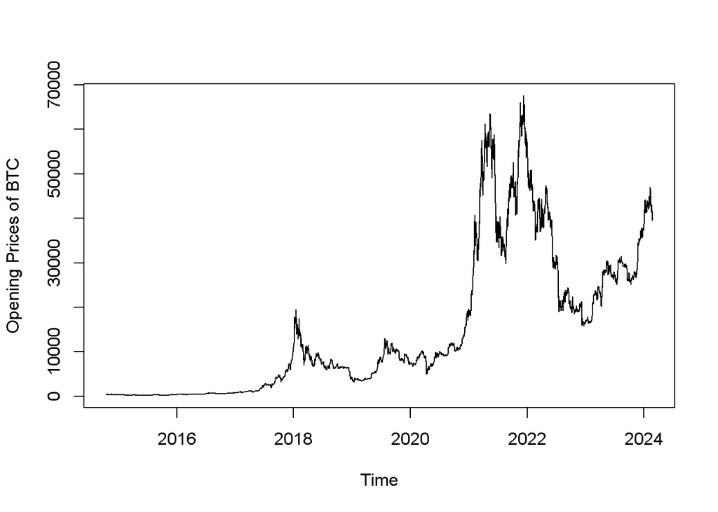

Daily Opening Prices of Bitcoin

To reduce the complexity of the time series and ‘smooth’ it, we average the prices of each month in accordance with

$$[\text{Monthly Prices}]_i = \Sigma_{i=1}^{30} [\text{Daily Prices}]_{i}
\cdot \frac{1}{30} \:\:\:\:, i = 1,2, \dots$$

Plotting the transformed monthly data we can see a smoother time series, with less variation and spikes. Whilst keeping the overall trends.

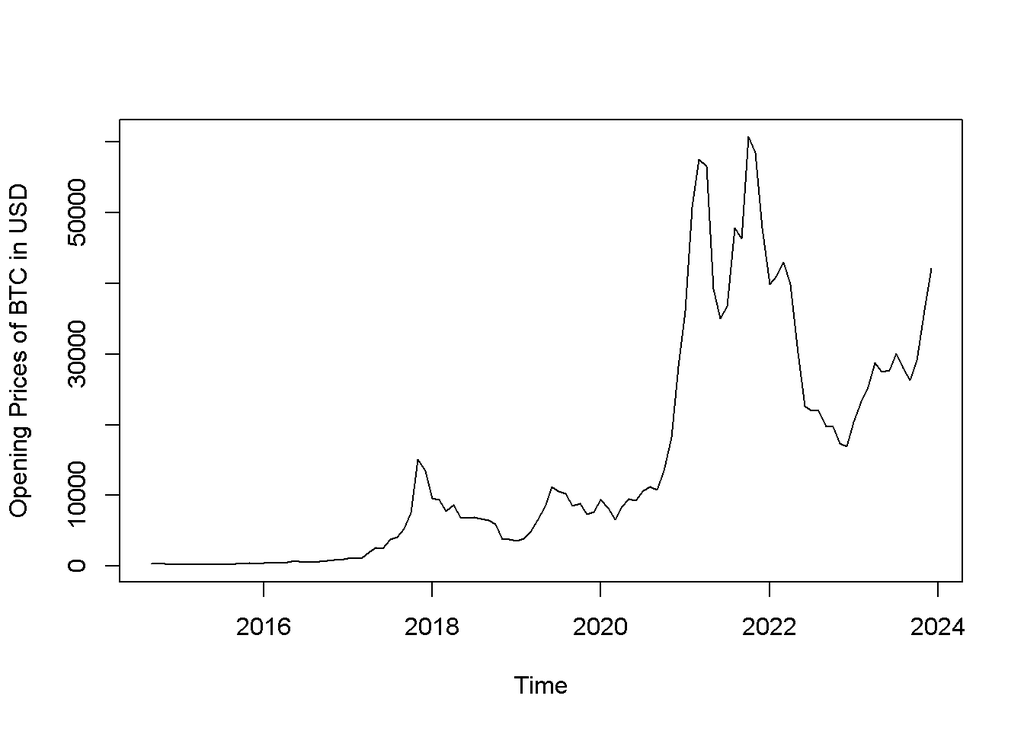

Monthly Opening Prices of Bitcoin

### Solution:

```r
# Selecting the previous year as test data, and remaining as training data.
train.data <- ts(monthly.data[1:100],
                    start = c(2014,9),
                    frequency = 12)

test.data <- as.ts(monthly.data[101:112],
                   start = c(2023,1),
                    frequency = 12)
```

### Task 3

Start by plotting the time series and examine the main features of the graphs, i.e., check whether there is a drift, a deterministic trend, a combination of drift and a deterministic trend, a seasonal component, any apparent sharp changes in behavior, any outlying observations,

### Solution

Plotting these two time series we see

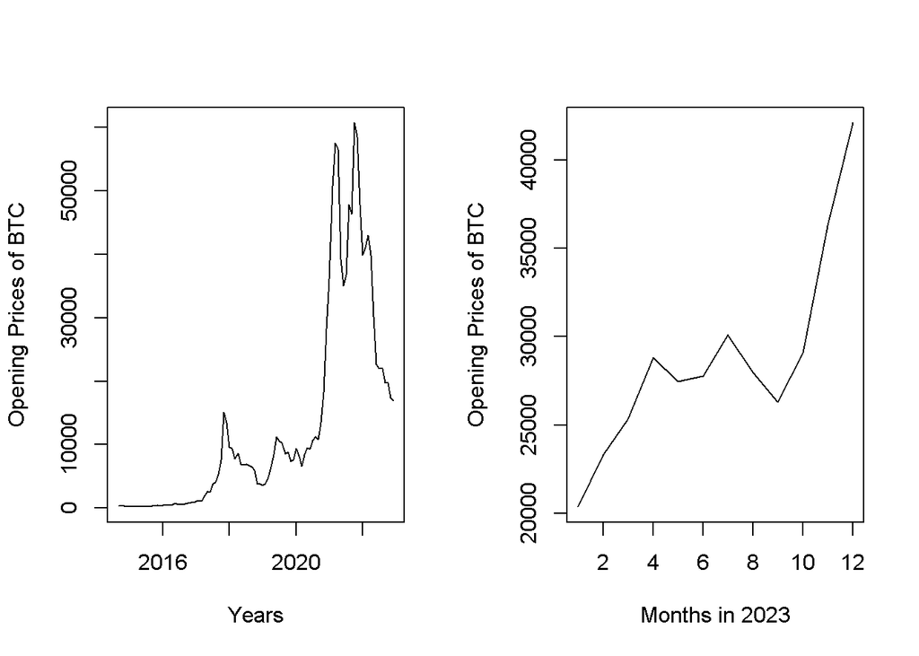

Therefore, we perform an natural logarithmic transformation to reduce the yet still - drastic fluctuations. Judging by the Figure below we see a substantial improvement of the training dataset - reseabling more of a linear times series with drift and various seasonalities.

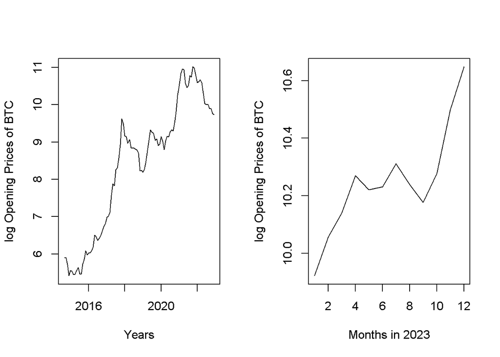

```r
log.test.data <- log(test.data, base = exp(1))
log.train.data <- log(train.data, base = exp(1))
par(mfrow=c(1,2))
plot(log.train.data,
     ylab = "log Opening Prices of BTC",
     xlab = "Years"
)

plot(log.test.data ,
     ylab = "log Opening Prices of BTC",
     xlab = "Months in 2023"
)
```

### Solution using S1 method

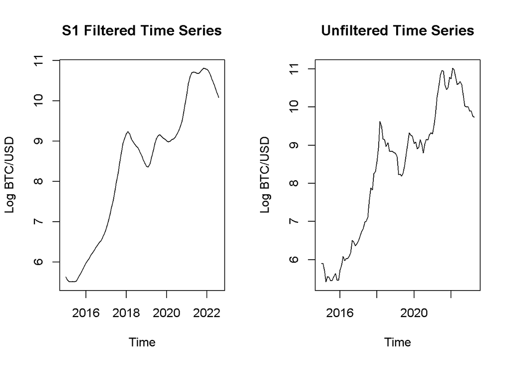

Followed by subtracting each

$$s_t = w_k - \frac{1}{d}
\Sigma_{i}^{d}w_i \: \:\: \: ,i,k = 1,2,\dots d$$

We get the following results;

```
##        Jan        Feb      March      April        May       June       July
## -0.3421268 -0.3371797 -0.4081076 -0.1866173 -0.1347215 -0.1733557 -0.2558456
##        Aug       Sept        Oct        Nov        Dec
## -0.3120946 -0.3925010 -0.4275887 -0.4453251 -0.5095459
```

We obtain de-seasonalized data by

$$d_ t = x_t - s_t$$
The re-estimate the means using the de-seasonalized data

$$\hat{m}_t = \frac{0.5d_{t-3} + d_{t-2} +
d_{t-1} + d_{t} + d_{t+1} + d_{t+2} + 0.5d_{t+3}}{6}$$
Followed by obtaining the residuals using the

$${\hat{Y}}_t = x_t - \hat{m}_t-
s_t$$

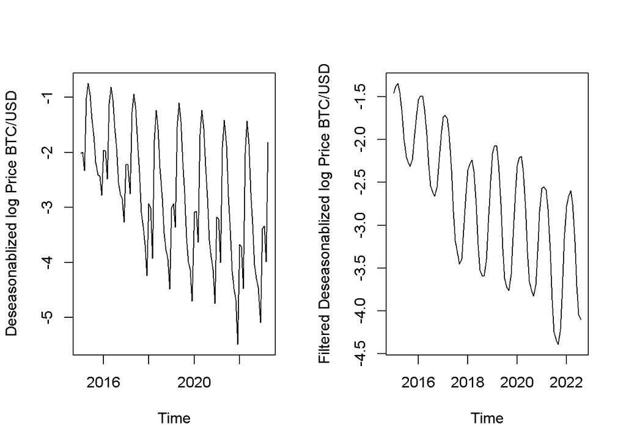

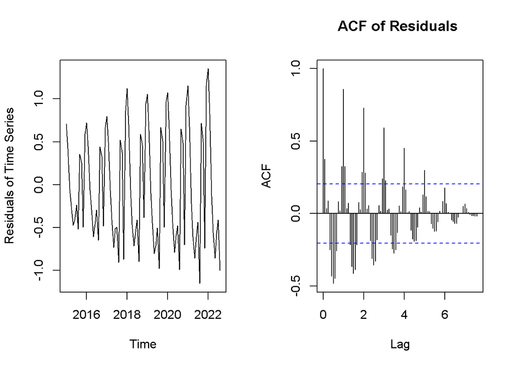

### Solution using S2 Method

Method S2 consist of elimination of trend and seasonal component by differencing.

The difference operator $\nabla_d$ is defined as

$$\nabla_d X_t = X_t - X-{t-d} =
(1-\mathcal{B}^d)X_t$$

where $\mathcal{B}$ is the backward shit operator defined as
$$\mathcal{B}X_t = X_{t-1}$$

Applying the classical decomposition model$X_t = m_t + s_t + Y_t$ where $m_t$ is a slowly changing function known as a trend component, $s_t$ is a function with known period d referred to as a seasonal component, and $Y_t$ is a random noise component that is stationary, if $Y_t$ is iid Gaussian White Noise then $\mathbf{E}[Y_t] = 0$. Applying the difference operator we get a de-seasonalized series with trend compontent $m_t - m_{t-d}$ and residual $Y_t - Y_d$.

Put mathematically:

$$\nabla_d X_t = m_t - m_{t-d} + Y_t -
Y_{t-d}$$

```r
# eliminate the seasonal component

log.data <- log(monthly.data, base = exp(1))

# eliminate the seasonal component
S2.lag12.diffed <- diff(log.data, lag = 12, differences = 1)


# eliminate the trend form the deseasonalized series
S2.trend.diffed <- diff(S2.lag12.diffed,differences = 1)
```

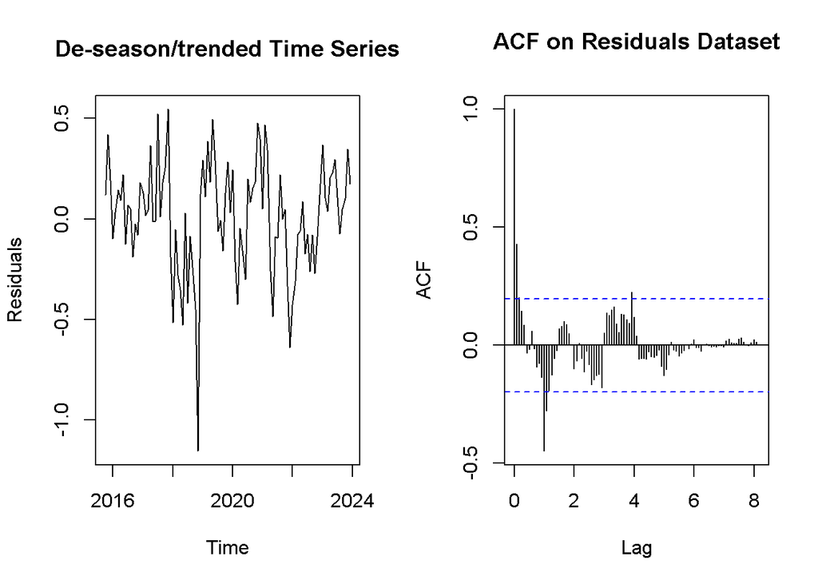

Differenced Method for de-seasonlized and de-trending Time series

### Task 5

Test if the residuals or the differenced series are iid Noise according to the methods in Chapter 1.6.

### Solution

The available testing methods we will be where we will be reviewing some of them are as follows

- Visually checking the sample autocorrelation function
- Protmanteau test
- Turning point test
- Difference-sign test
- Mann-Kendall Rank test
- Checking for normality
  - Histogram
  - qq plot
  - Normality test
    - Shapiro-Wilks test
    - Shapiro–Francia test
    - Jarque–Beratest
    - Anderson–Darling test

We will systematically check all of these methods to see whether or not the time series residuals has a dependence structure or not. The typical hypothesis tests reviews if
$$\begin{align*}
\text{H}_0 &= \text{The Time Series is iid Noise, e.g. no dependence
structure among residuals}\\
\text{H}_1 &= \text{The Time Series is } \mathbf{\text{NOT}} \text{
iid Noise, e.g. there is a possible dependece structure among residuals}
\end{align*}$$

#### Sample autocorrelation function

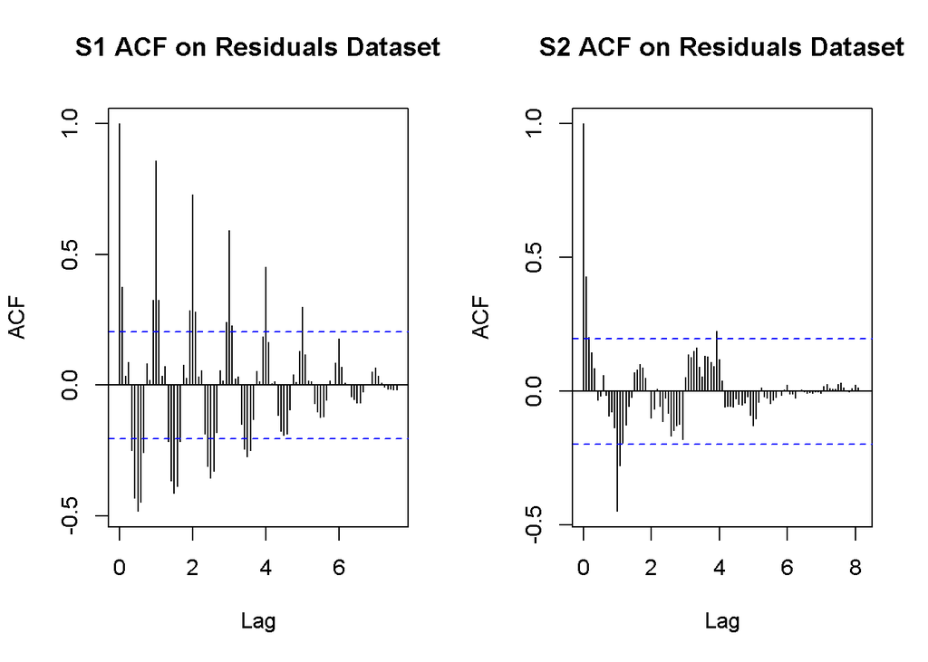

ACF for S1 and S2 methods on time series

#### Protmanteau test

The Portmanteau test continues and builds upon the idea of autorrelation. Let $\hat{\rho} (j)$ denote the sample autocorrelation value of lag $j$. Then if $Y_1 ,Y_2, \dots, Y_n$ is an iid sequence, for large $n$
$$Q = n \Sigma_{j=1}^{h} \hat{\rho} (j) \:\:\:, j =
1,\dots,h$$

$Q$ is approximately distributed as the sum of squares of the independent $\mathcal{N}(0, 1)$ random variables, yielding that $\sqrt{n} \hat{\rho} (j)$ for $j=1,\dots,h$ is $\chi^{2}(h)$ distributed with $h$ degrees of freedom.\ Ljung and Box refined this test with an better approximation of the $\chi^2$ distribution using

$$Q_{LB} = n(n+2) \Sigma_{j=1}^{h}
\frac{\hat{\rho}(j)}{n-j} \:\:\:, j = 1,\dots,h$$

We shall now test both methods to check for independence

```r
# Box-Pierce Version of iid Sequence test
Box.test(S1.Residuals,type = "Box-Pierce", lag = 1)
```

```
##
##  Box-Pierce test
##
## data:  S1.Residuals
## X-squared = 13.004, df = 1, p-value = 0.0003109
```

```r
Box.test(S2.Residuals,type = "Box-Pierce", lag = 1)
```

```
##
##  Box-Pierce test
##
## data:  S2.Residuals
## X-squared = 18.228, df = 1, p-value = 1.96e-05
```

```r
# Ljung-Box Version of iid Sequence test
Box.test(S1.Residuals,type = "Ljung-Box", lag = 1)
```

```
##
##  Box-Ljung test
##
## data:  S1.Residuals
## X-squared = 13.432, df = 1, p-value = 0.0002473
```

```r
Box.test(S2.Residuals,type = "Ljung-Box", lag = 1)
```

```
##
##  Box-Ljung test
##
## data:  S2.Residuals
## X-squared = 18.786, df = 1, p-value = 1.463e-05
```

Both methods reject the null-hypothesis H$_0$ with p-value $< 0.000$ for both residual time series. Implying that these series are not an iid sequence and has a clear dependence structure.

#### Turning point test

The method by which the turning point test the residual for an iid sequence is as follows. If $Y_1, \dots Y_n$ is a sequence of observations, then there is a turning point at time $i$ if $Y_{i-1} < Y_i$ and $Y_i > Y_{i+1}$, or alternatively $Y_{i-1} > Y_i$ and $Y_i < Y_{i+1}$. Then

If $T$ is the number of turning points of an iid sequence of length $n$, the for large $n$
$$T \in
\mathcal{N}(\frac{2(n-2)}{3}, \frac{16n - 29}{90})$$

Thus, we reject H$_0$ whenever $\frac{|T-\mu_T |}{\sigma_T} > \Phi_{1-\frac{\alpha}{2}}$ where $\Phi_{1-\frac{\alpha}{2}}$ is the 1- $\frac{\alpha}{2}$ quantile of the standard normal distribution $\mathcal{N}(0,1)$.

```r
library(randtests)
turning.point.test(S1.Residuals)
```

```
##
##  Turning Point Test
##
## data:  S1.Residuals
## statistic = -3.9958, n = 92, p-value = 6.447e-05
## alternative hypothesis: non randomness
```

```r
turning.point.test(S2.Residuals)
```

```
##
##  Turning Point Test
##
## data:  S2.Residuals
## statistic = -0.88212, n = 99, p-value = 0.3777
## alternative hypothesis: non randomness
```

From the turning point test output, H$_0$ was rejected for method S1, however the test was unable to reject the S2 methods residuals. Implying that they may be an iid sequence

#### Difference-sign test

Let $Y_1, \dots Y_n$ be a sequence of observations, then we count the number $S$ of values $i$ such that $Y_i > Y_{i-1}$.

If $Y_1, \dots Y_n$ is an iid sequence, then for large $n$
$$S \in \mathcal{N} ( \frac{n-1}{2},
\frac{n+1}{12})$$

Thus, we reject H$_0$ whenever $\frac{|S -\frac{n-1}{2} |}{|\sqrt{\frac{n+1}{12}}|} > \Phi_{1-\frac{\alpha}{2}}$ where $\Phi_{1-\frac{\alpha}{2}}$ is the 1- $\frac{\alpha}{2}$ quantile of the standard normal distribution $\mathcal{N}(0,1)$.

Time Series literature argues however that the the difference-sign test must be used with caution. A set of observations exhibiting a cyclic component will pass the difference-sign test for randomness, since roughly half of the observations will be points of increase.

```r
difference.sign.test(S1.Residuals)
```

```
##
##  Difference Sign Test
##
## data:  S1.Residuals
## statistic = -3.0533, n = 92, p-value = 0.002263
## alternative hypothesis: nonrandomness
```

```r
difference.sign.test(S2.Residuals)
```

```
##
##  Difference Sign Test
##
## data:  S2.Residuals
## statistic = 0.34641, n = 99, p-value = 0.729
## alternative hypothesis: nonrandomness
```

Similar to the turning point test output, H$_0$ was rejected for method S1 residuals, however the test was unable to reject the S2 methods residuals. Implying that they may be an iid sequence.

#### Mann-Kendall Rank test

The rank test is especially useful for detecting a linear trend in the data. Define $\mathcal{P}$ to be the number of pairs $(i,j)$ such that $Y_j > Y_i$ and $j>i$, $i = 1, \dots, n-1$ If $Y_1, \dots Y_n$ is an iid sequence, then for large $n$

$$\mathcal{P} \in \mathcal{N}
(\frac{n(n-1)}{4}, \frac{n(n-1)(2n+5)}{72})$$

We would reject H$_0$ if $\frac{|\mathcal{P} -\frac{n(n-1)}{4} |}{|\sqrt{\frac{n(n-1)(2n+5)}{72}}|} > \Phi_{1-\frac{\alpha}{2}}$ where $\Phi_{1-\frac{\alpha}{2}}$ is the 1- $\frac{\alpha}{2}$ quantile of the standard normal distribution $\mathcal{N}(0,1)$.

```r
rank.test(S1.Residuals)
```

```
##
##  Mann-Kendall Rank Test
##
## data:  S1.Residuals
## statistic = -0.82971, n = 92, p-value = 0.4067
## alternative hypothesis: trend
```

```r
rank.test(S2.Residuals)
```

```
##
##  Mann-Kendall Rank Test
##
## data:  S2.Residuals
## statistic = -0.21464, n = 99, p-value = 0.83
## alternative hypothesis: trend
```

The Mann-Kendall Rank test was unable to reject both H$_0$ for both S1 and S2 methods of the residuals. Implying that both of them may be an iid sequence.

#### Checking for normality

In case the series has a normal distribution, we would then be able to infer stronger assumptions and make better predictions.

We begin visually, reviewing the normality assumption of the residuals using quantile plots

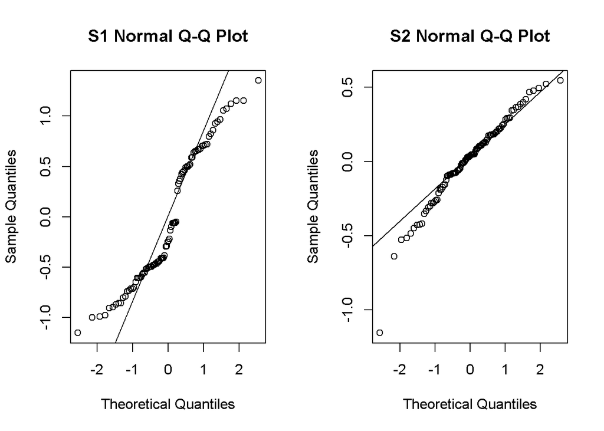

Q-Q plots for Normality of Residuals of S1 and S2 Method

```r
# Normality Plots
par(mfrow=c(1,2))
qqnorm(S1.Residuals,
       main = "S1 Normal Q-Q Plot")
qqline(S1.Residuals)
qqnorm(S2.Residuals,
       main = "S2 Normal Q-Q Plot")
qqline(S2.Residuals)
```

From Figure 10, it seems that the time series may be normally distributed indeed for S2, however it may be a stretch to assume the S1 residuals are normal. We must perform a statistical hypothesis test to evaluate it more carefully and accurately.

Proceeding with the statistical tests, the Jarque–Bera statistic tests the residuals of the fit for normality based on the observed skewness and kurtosis. Atleast for S1 residuals it appears that the residuals have some non-normal skewness and kurtosis to the time series. The Shapiro–Wilk statistic tests the residuals of the fit for normality based on the empirical order statistics. Below we see the results of both tests

```r
shapiro.test(S1.Residuals)
```

```
##
##  Shapiro-Wilk normality test
##
## data:  S1.Residuals
## W = 0.92675, p-value = 6.651e-05
```

```r
shapiro.test(S2.Residuals)
```

```
##
##  Shapiro-Wilk normality test
##
## data:  S2.Residuals
## W = 0.96096, p-value = 0.004993
```

```r
jarque.bera.test(S1.Residuals)
```

```
##
##  Jarque Bera Test
##
## data:  S1.Residuals
## X-squared = 7.2991, df = 2, p-value = 0.026
```

```r
jarque.bera.test(S2.Residuals)
```

```
##
##  Jarque Bera Test
##
## data:  S2.Residuals
## X-squared = 27.084, df = 2, p-value = 1.315e-06
```

```r
library(nortest)
ad.test(S1.Residuals)
```

```
##
##  Anderson-Darling normality test
##
## data:  S1.Residuals
## A = 2.8171, p-value = 3.834e-07
```

```r
ad.test(S2.Residuals)
```

```
##
##  Anderson-Darling normality test
##
## data:  S2.Residuals
## A = 0.62743, p-value = 0.09938
```

```r
sf.test(S1.Residuals)
```

```
##
##  Shapiro-Francia normality test
##
## data:  S1.Residuals
## W = 0.93301, p-value = 0.0003143
```

```r
sf.test(S2.Residuals)
```

```
##
##  Shapiro-Francia normality test
##
## data:  S2.Residuals
## W = 0.95682, p-value = 0.00361
```

#### Normality and iid sequence Conclusion:

The Residuals are not normal, nor are they independent. Although some visual plots show resemblance of normality and some test are unable to reject H$_0$ e.g. implying the residuals are iid. However, several methods points to the fact that there is a clear dependence structure and many p-values suggest strongly non-normality is present within the time series.

### Task 6

Regardless of the conclusion from 5, use the results from method S1 to forecast the forthcoming year (just using the estimated trend and the estimated seasonal component) and compare it to the “correct answer”.

### Solution

Proceeding with forecasting the year 2023 using the S1 Method for decomposition from 2014 - 2022, we firstly re-familiarize the reader with the derivations of the S1 Method.

$$\begin{align}
X_t &= m_t + s_t + Y_t, \:\: t=1,\dots n,\: \text{ where },
\mathbf{E} [Y_t ] = 0\\
m_t &= \frac{0.5x_{t-3} + x_{t-2} + x_{t-1} + x_{t} + x_{t+1} +
x_{t+2} + 0.5x_{t+3}}{6}\\
s_t &= w_k - \frac{1}{d} \Sigma_{i}^{d}w_i \: \:\: \: ,i,k =
1,2,\dots d\\
d_t &= x_t - s_t\\
&\text{Then re-estimate the means using the de-seasonalized data}\\
\hat{m}_t &= \frac{0.5d_{t-3} + d_{t-2} + d_{t-1} + d_{t} + d_{t+1}
+ d_{t+2} + 0.5d_{t+3}}{6}\\
\hat{Y}_t &= x_t - \hat{m}_t - s_t
\end{align}$$

In our case, because we assume $\mathbf{E} [Y_t ] = 0$, which due to our non-normality in the residuals as seen above in Task 5 is in fact incorrectly assumed - we will be producing a biased forecasting result. Nevertheless, suppose $\mathbf{E} [Y_t ] = 0$ is true, then we may see from Equation 7 that in order to forecast $x_t$ we simply need to plugin the values for $\hat{m}_t$ and $s_t$, mathematically speaking

$$\hat{x}_{t}^{Forcast} =\hat{m}_t +
s_t$$

Recalling the results from Task 4, our $s_t$ values are

| Months | Jan | Feb | March | April | May | June | July | Aug | Sept | Oct | Nov | Dec |
| --- | --- | --- | --- | --- | --- | --- | --- | --- | --- | --- | --- | --- |
| $s_t$ | -0.34 | -0.33 | -0.41 | -0.18 | -0.14 | -0.17 | -0.25 | -0.31 | -0.39 | -0.43 | -0.45 | -0.51 |

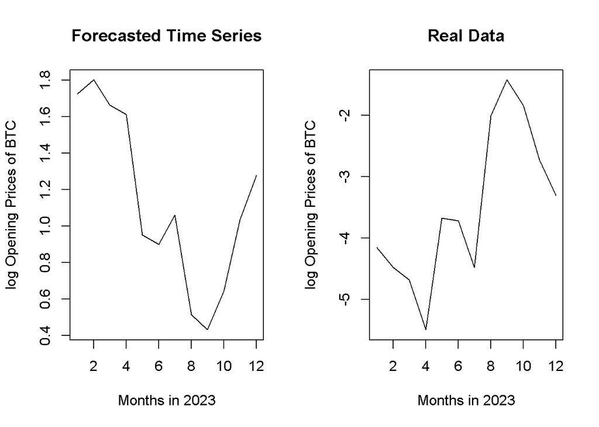

12 Month Forecast of Monthly BTC/USD Prices in 2023

## General Conclusion

One may thus conclude that such a linear time series model is insufficient or poorly specified for using on this kind of data set. As we saw under Task 5, the stationary assumption was violated as well as the normality assumption. In addition, intuitively the assumption of the model that $s_t = s_{t+d}$ may be too strong - since the concurrency market is highly volatile and adjusting rapidly around regulatory realities as well as other impacts for instance Elon Musks tweets. Resulting in this classical decomposition being unsuitable to forecast accurately monthly prices of Bitcoin.

# Labb 2 Solutions

## Task 2

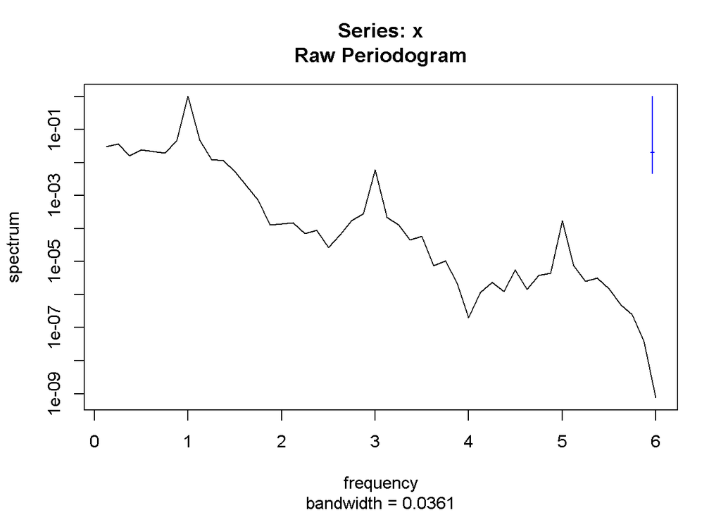

```r
S1.Method.ts <- as.ts(S1.DS.Results)
S2.Method.ts <- as.ts(S2.trend.diffed)
# Calculating the perriodogram
S1.spc <- spectrum(S1.Method.ts,plot="T")
```

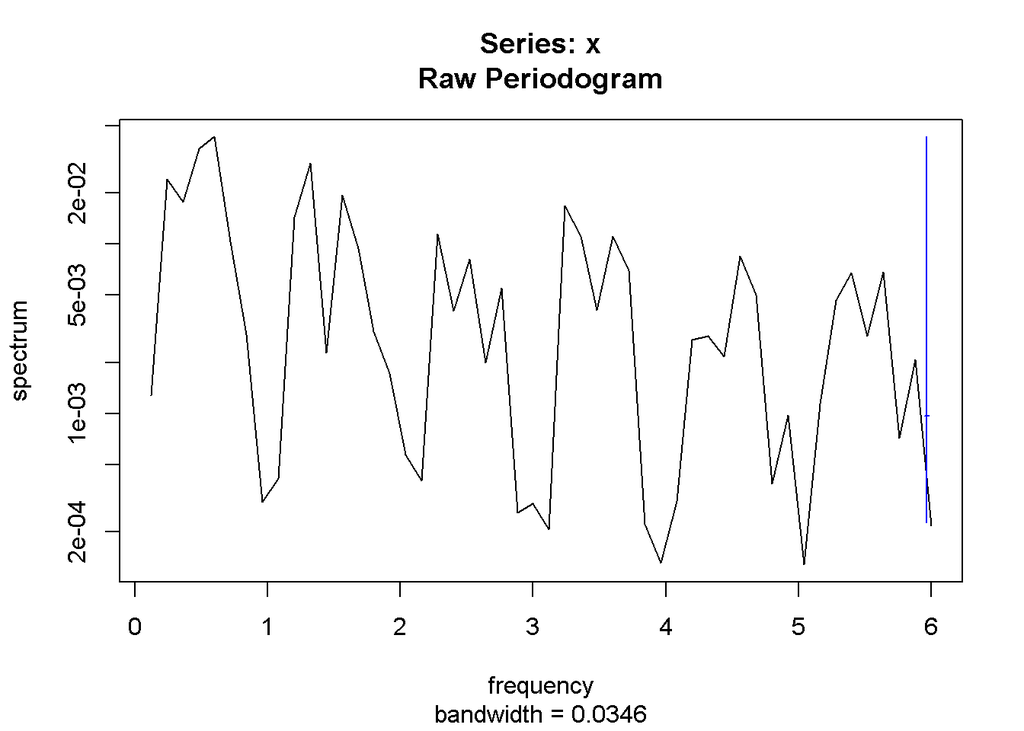

```r
S2.spc <- spectrum(S2.Method.ts,plot="T")
```

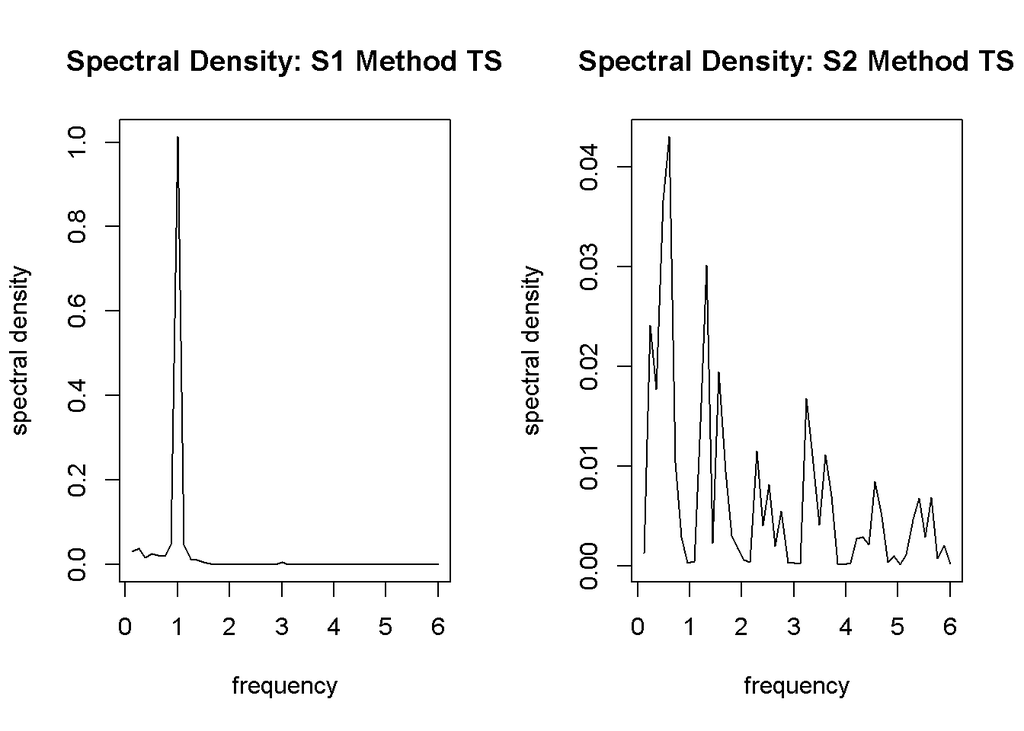

```r
#Extracting the frequencies at which the spectral density is estimated
S1.spx <- S1.spc$freq
S2.spx <- S2.spc$freq
#Extracting the spectral density estimates, scaled by 1/frequency
S1.spy <- S1.spc$spec
S2.spy <- S2.spc$spec


#Plotting the Spectral density
par(mfrow=c(1,2))
plot(S1.spy~S1.spx,xlab="frequency",ylab="spectral density",type="l",main="Spectral Density: S1 Method TS")
plot(S2.spy~S2.spx,xlab="frequency",ylab="spectral density",type="l",main="Spectral Density: S2 Method TS")
```

For the method S1 the spectral density clearly shows a frequency of 1 e.g. 1 year frequency. Although, It seems as S2 method doesn’t produce a clear frequency, a possible interpretation is that there’s a more complex underlying process that is not accounted for within the data.

## Task 3

Differencing the times series

```r
library(forecast)
nsdiffs(S1.Method.ts)
```

```
## [1] 1
```

```r
ndiffs(S1.Method.ts)
```

```
## [1] 1
```

```r
nsdiffs(S2.Method.ts)
```

```
## [1] 0
```

```r
ndiffs(S2.Method.ts)
```

```
## [1] 0
```

Since poor results are shown for S2 method, firstly with the incomplete spectral density est. and now with the subsequent 0 differencing required for stationarity we omit the S2 method times series and proceed with solely the S1 time series.

```r
TS.diff <- diff(S1.Method.ts, lag = nsdiffs(S1.Method.ts), differences = ndiffs(S1.Method.ts) )
```

## Task 4

Testing for stationarity using the previous methods in lab 1, on the newly differenced data yields

We conduct the augment dicker fuller test, to check for stationarity within our differenced time series. The null hypothesis is wether the time series is a random walk versus the alternative hypothesis which implies the time series is a stationary process.

```r
library(tseries)

adf.test(TS.diff)
```

```
##
##  Augmented Dickey-Fuller Test
##
## data:  TS.diff
## Dickey-Fuller = -18.949, Lag order = 4, p-value = 0.01
## alternative hypothesis: stationary
```

We reject the null hypothesis because the p-value is smaller than 0.05.

This indicates that the time series is stationary. To put it another way, it has some time-independent structure and does exhibit constant variance over time.

## Task 5

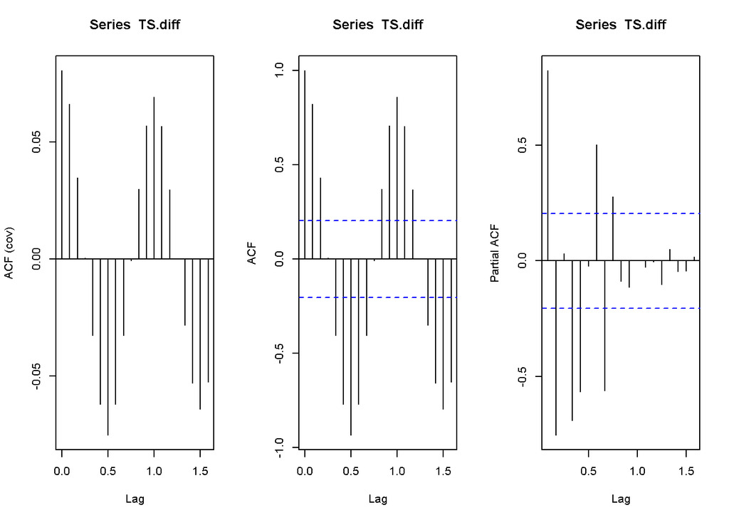

```r
par(mfrow=c(1,3))
acf(x = TS.diff,
    type = c("covariance"))
acf(TS.diff)
pacf(TS.diff)
```

## Task 6

Fitting the ARMA model for our time series

```r
# Finding the best order using AIC, AR
ar_mod = ar(TS.diff,order=25,aic=T) # Search among p=1,2,,...,25
ar_mod$aic # differences in AIC between each model and the best-fitting mode
```

```
##          0          1          2          3          4          5          6
## 322.353895 222.027874 147.663205 149.569157  92.949588  59.964603  61.917061
##          7          8          9         10         11         12         13
##  37.473650   5.253333   0.000000   1.295797   2.122424   4.122366   6.049363
##         14         15         16         17         18         19         20
##   8.048536   9.100220  10.877405  12.676852  14.501922  16.473642  18.459517
##         21         22         23         24         25
##  20.281768  22.239821  24.210410  26.184270  28.099085
```

```r
# 'Best', aka lowest AIC is 0 for AR(9)


# Regular ARMA(1,1)
Model_1 <- arima(TS.diff,
                 order=c(1,0,1),
                 method="ML",
                 include.mean=F)
Model_1$aic
```

```
## [1] -146.1612
```

```r
# AIC -146





# Fitting ARMA(9,1) model with ML-estimation
Model_2 <- arima(TS.diff,order=c(9,0,1),method="ML", include.mean=F)
Model_2$aic
```

```
## [1] -482.7571
```

```r
# Lowest AIC -482.75
```

## Task 7

Testing the models residuals below to judge the models goodness of fit using chapter 1.6 and 5.3 methods.

```r
Mod2_res <- Model_2$residuals
# The portmanteau tests
Box.test(Mod2_res)
```

```
##
##  Box-Pierce test
##
## data:  Mod2_res
## X-squared = 0.073265, df = 1, p-value = 0.7866
```

```r
Box.test(Mod2_res,type = "Ljung-Box")
```

```
##
##  Box-Ljung test
##
## data:  Mod2_res
## X-squared = 0.075707, df = 1, p-value = 0.7832
```

```r
# The turning point test, The difference-sign test and The rank test

library(randtests)
turning.point.test(Mod2_res)
```

```
##
##  Turning Point Test
##
## data:  Mod2_res
## statistic = -0.083712, n = 91, p-value = 0.9333
## alternative hypothesis: non randomness
```

```r
difference.sign.test(Mod2_res)
```

```
##
##  Difference Sign Test
##
## data:  Mod2_res
## statistic = 0, n = 91, p-value = 1
## alternative hypothesis: nonrandomness
```

```r
rank.test(Mod2_res)
```

```
##
##  Mann-Kendall Rank Test
##
## data:  Mod2_res
## statistic = 2.1289, n = 91, p-value = 0.03326
## alternative hypothesis: trend
```

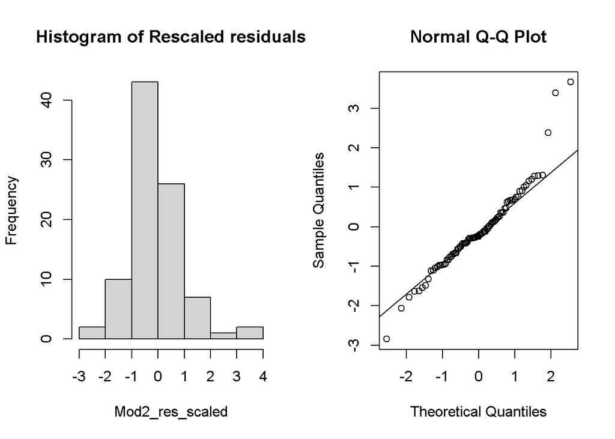

```r
# -----------------------------------------------------------------------
# Normality checking

par(mfrow=c(1,2))

# Histogram of rescaled residuals
Mod2_res_scaled <- Mod2_res/sqrt(Model_2$sigma2)
hist(Mod2_res_scaled, main="Histogram of Rescaled residuals")

# qq-plot
qqnorm(Mod2_res_scaled)
qqline(Mod2_res_scaled)
```

```r
par(mfrow=c(1,1))

# Normality tests
shapiro.test(Mod2_res)
```

```
##
##  Shapiro-Wilk normality test
##
## data:  Mod2_res
## W = 0.94047, p-value = 0.0004174
```

```r
library(tseries)
jarque.bera.test(Mod2_res)
```

```
##
##  Jarque Bera Test
##
## data:  Mod2_res
## X-squared = 42.533, df = 2, p-value = 5.809e-10
```

```r
library(nortest)
ad.test(Mod2_res)
```

```
##
##  Anderson-Darling normality test
##
## data:  Mod2_res
## A = 1.1852, p-value = 0.004072
```

```r
sf.test(Mod2_res)
```

```
##
##  Shapiro-Francia normality test
##
## data:  Mod2_res
## W = 0.93242, p-value = 0.0003178
```

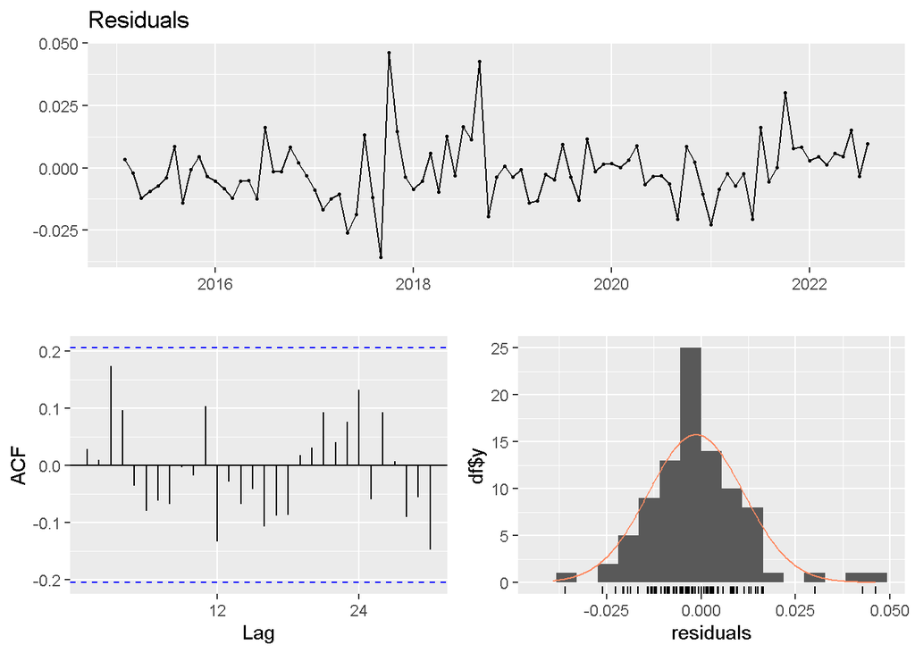

```
##
##  Ljung-Box test
##
## data:  Residuals
## Q* = 12.471, df = 18, p-value = 0.822
##
## Model df: 0.   Total lags used: 18
```

```r
checkresiduals(Mod2_res)
```

## Task 8

```r
coef.mod2 <- coeftest(Model_2)
coef.mod2
```

```
##
## z test of coefficients:
##
##        Estimate  Std. Error  z value Pr(>|z|)
## ar1  0.89825550  0.10727743   8.3732   <2e-16 ***
## ar2 -0.08306871  0.14693646  -0.5653   0.5718
## ar3  0.10096279  0.10861497   0.9295   0.3526
## ar4 -0.00067667  0.01884597  -0.0359   0.9714
## ar5 -0.00049181  0.01625149  -0.0303   0.9759
## ar6 -0.98968371  0.01177085 -84.0792   <2e-16 ***
## ar7  0.88833321  0.10810768   8.2171   <2e-16 ***
## ar8 -0.08013205  0.14778993  -0.5422   0.5877
## ar9  0.10113555  0.10859669   0.9313   0.3517
## ma1  0.99999595  0.03764587  26.5632   <2e-16 ***
## ---
## Signif. codes:  0 '***' 0.001 '**' 0.01 '*' 0.05 '.' 0.1 ' ' 1
```

The results of the function yields significant autoregressive orders for AR(1), AR(6), AR(7) and for the moving average MA(1). This is somewhat inconsistent with the minimum order selected by the AR estimation using AIC previously, as it yielded 9.

## Task 9

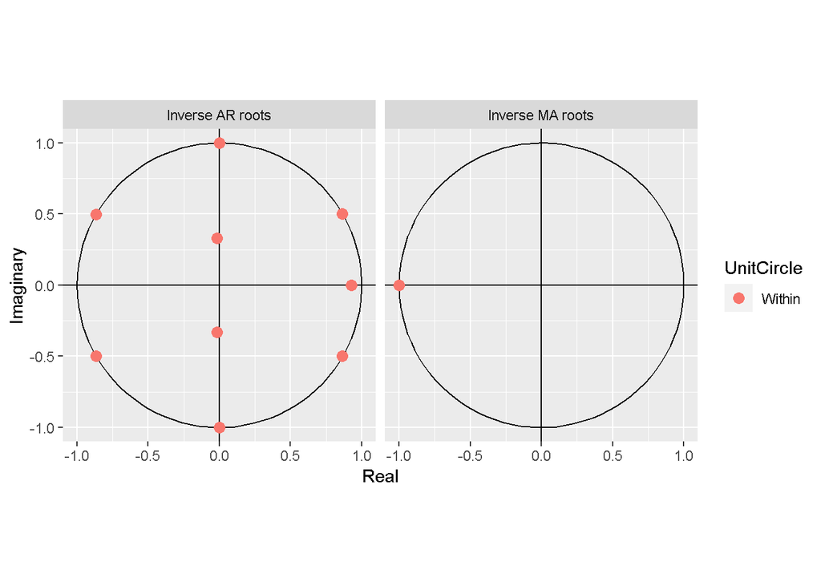

```r
autoplot(Model_2)
```

## Task 10

Fitting a SARIMA model on the undifferenced dataset

```r
Model_3 <- arima(log.train.data,
                  order = c(9,0,1),
                  seasonal = c(1,0,1)
                 )
Model_3
```

```
##
## Call:
## arima(x = log.train.data, order = c(9, 0, 1), seasonal = c(1, 0, 1))
##
## Coefficients:
##          ar1     ar2      ar3     ar4      ar5     ar6     ar7      ar8
##       0.4451  0.8413  -0.2538  0.0406  -0.1442  0.1314  0.0970  -0.0836
## s.e.  0.1568  0.1986   0.1496  0.1427   0.1400  0.1595  0.1532   0.1286
##           ar9     ma1    sar1     sma1  intercept
##       -0.0926  0.8953  0.8612  -0.9999     8.1582
## s.e.   0.1075  0.1227  0.1224   0.1426     0.8712
##
## sigma^2 estimated as 0.02932:  log likelihood = 29.35,  aic = -30.7
```

```r
# Reviewing the quality

coef.mod3 <- coeftest(Model_3)
coef.mod3
```

```
##
## z test of coefficients:
##
##            Estimate Std. Error z value  Pr(>|z|)
## ar1        0.445052   0.156816  2.8380  0.004539 **
## ar2        0.841272   0.198636  4.2352 2.283e-05 ***
## ar3       -0.253849   0.149634 -1.6965  0.089797 .
## ar4        0.040558   0.142658  0.2843  0.776177
## ar5       -0.144169   0.139955 -1.0301  0.302957
## ar6        0.131428   0.159521  0.8239  0.410000
## ar7        0.096981   0.153231  0.6329  0.526793
## ar8       -0.083590   0.128613 -0.6499  0.515733
## ar9       -0.092581   0.107546 -0.8608  0.389321
## ma1        0.895277   0.122733  7.2945 2.997e-13 ***
## sar1       0.861237   0.122374  7.0378 1.953e-12 ***
## sma1      -0.999950   0.142589 -7.0128 2.336e-12 ***
## intercept  8.158242   0.871179  9.3646 < 2.2e-16 ***
## ---
## Signif. codes:  0 '***' 0.001 '**' 0.01 '*' 0.05 '.' 0.1 ' ' 1
```

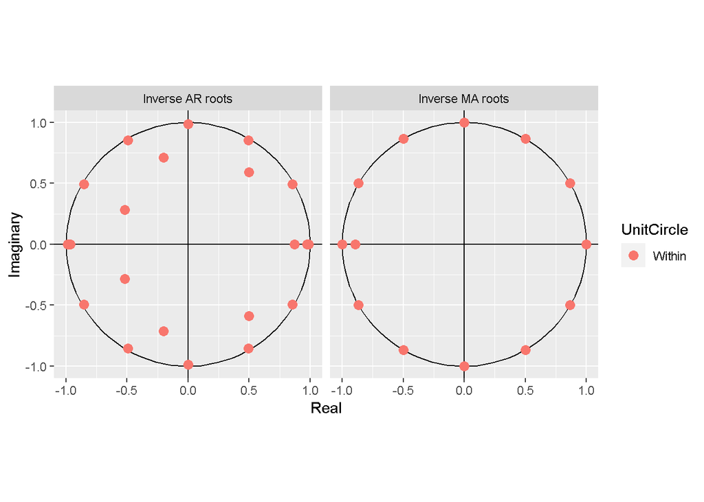

```r
autoplot(Model_3)
```

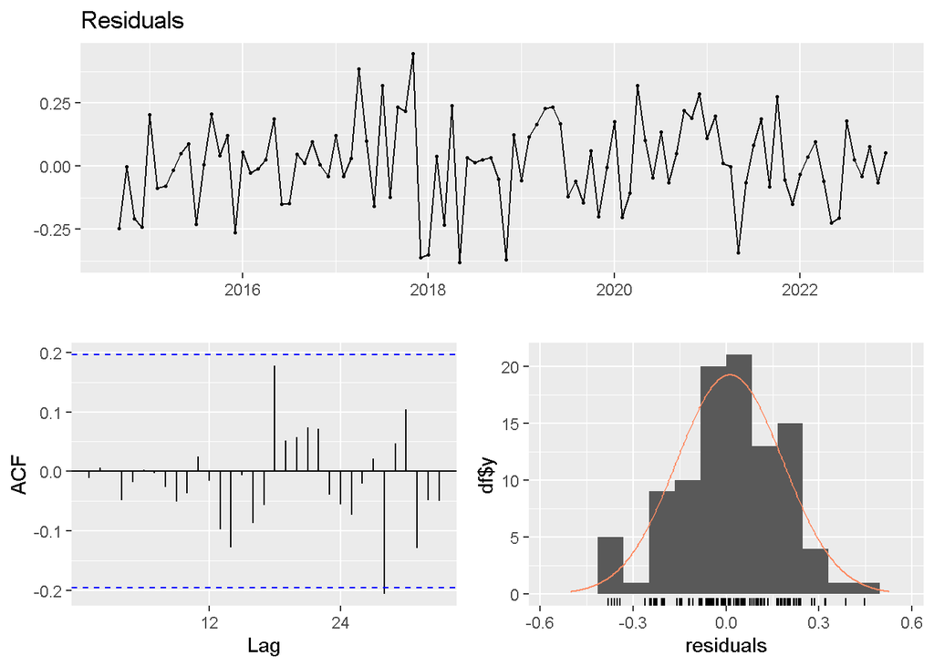

```
##
##  Ljung-Box test
##
## data:  Residuals
## Q* = 10.03, df = 20, p-value = 0.9676
##
## Model df: 0.   Total lags used: 20
```

```r
checkresiduals(Model_3$residuals)
```

## Task 11

```r
forecast_mod3 <- predict(object = Model_3, newdata = log.test.data, n.ahead = 12, interval = 'confidence')
UP_CI <- forecast_mod3$pred+2*forecast_mod3$se
LOW_CI <- forecast_mod3$pred-2*forecast_mod3$se
```

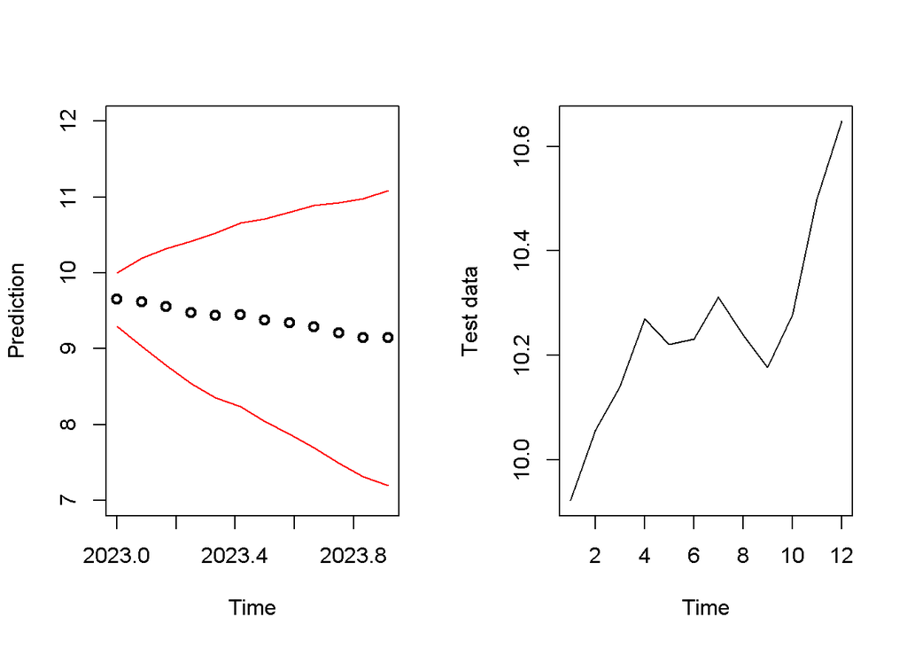

```r
par(mfrow=c(1,2))

plot(forecast_mod3$pred,
     ylab = "Prediction",
     ylim = c(7,12),
     lwd = 2,
     type = "b")
lines(UP_CI, col = "red")
lines(LOW_CI,col = "red")



plot(log.test.data,
     ylab = "Test data")
```

Calculating MSE yields

```r
MSE3 = sum((as.numeric(forecast_mod3$pred) - as.numeric(log.test.data))^2)
MSE3
```

```
## [1] 10.17593
```

```r
# 10.17593
```

## Task 12

Lets apply auto.arima to see whether we get a better MSE than 10.17593.

[output not shown]

[output not shown]

```r
forecast_mod4 <- predict(object = Model_4, newdata = log.test.data, n.ahead = 12, interval = 'confidence')
UP_CI <- forecast_mod4$pred+2*forecast_mod4$se
LOW_CI <- forecast_mod4$pred-2*forecast_mod4$se
```

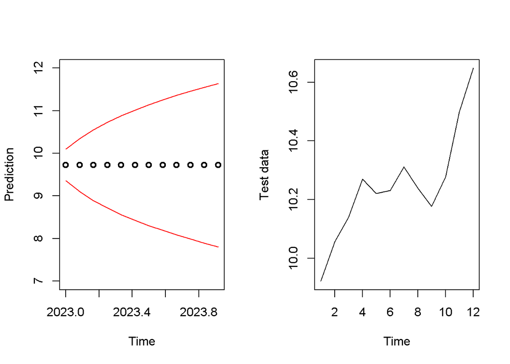

```r
par(mfrow=c(1,2))

plot(forecast_mod4$pred,
     ylab = "Prediction",
     ylim = c(7,12),
     lwd = 2,
     type = "b")
lines(UP_CI, col = "red")
lines(LOW_CI,col = "red")



plot(log.test.data,
     ylab = "Test data")
```

Calculating MSE yields

```r
MSE4 = sum((as.numeric(forecast_mod4$pred) - as.numeric(log.test.data))^2)
MSE4
```

```
## [1] 3.722912
```

```r
# 3.722912
```

Auto arima yielded the lowest MSE,

```
## [1] 1261.122
```

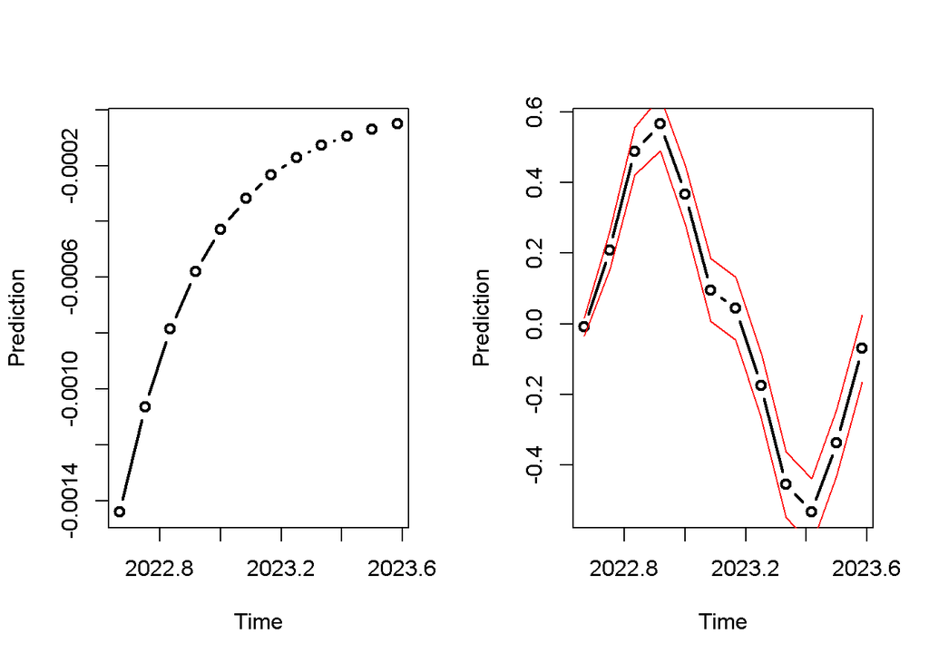

```
## [1] 1258.881
```

```r
MSE1
```

```
## [1] 1261.122
```

```r
MSE2
```

```
## [1] 1258.881
```

```r
MSE3
```

```
## [1] 10.17593
```

```r
MSE4
```

```
## [1] 3.722912
```

To minimize MSE as well as the complexity, Model 4 choosen by the auto arima